# class1-d

February 24, 2020

## 1. Preparing R

Load packages

```r
library("tidyverse")
```

This should install readr, tidyr, dplyr, purr, stringr, ggplot2, tibble, and forcats.

## 2. Importing data

In base R, we use `read.table`, `read.csv`, `read.delim`, etc. to import data. The problem with these functions is that they often coerce characters and other data types into factors. The tidyverse package `readr` guesses the data type of each column and converts types when appropriate (but does NOT convert strings to factors automatically). We will be using `readr` exclusively to import data in this class.

## readr

The typical commands used to input data using `readr` are below:

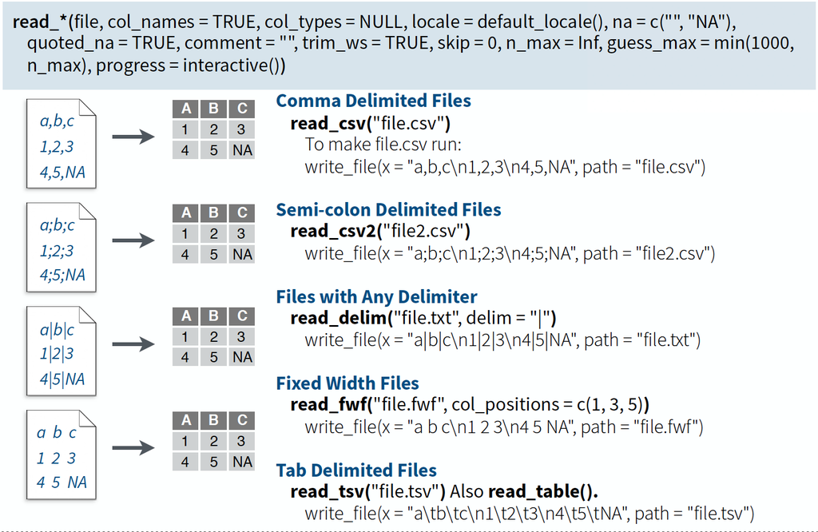

## readr (cont’d)

Using some of the following arguments makes it easier to control how we want to input the data.

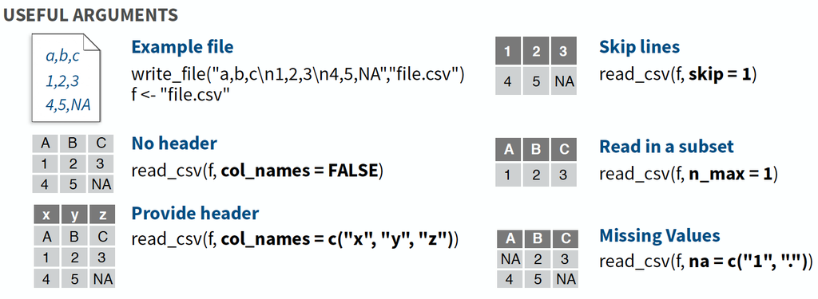

**Note**: All of these functions can also be used in an interactive manner via `Environment` > `Import Dataset` > `From Text (readr)`

## Next step: Import

- RNA read counts
- Experimental metadata

## A. RNA read counts

```r
count_summary_rna <- read_delim("1-class1/data/input/count_summary_rna.tsv",
                                delim = "\t",
                                escape_double = FALSE,
                                trim_ws = TRUE)
```

## B. Experimental metadata

```r
experiment_metadata <- read_delim("1-class1/data/input/experiment-metadata.txt",
                                  "\t",
                                  escape_double = FALSE,
                                  trim_ws = TRUE)
```

## 3. Getting familiar with the data

R provides many functions to examine features of a data object

- `class()` - what kind of object is it (high-level)?
- `str()` - what is the structure of the object?
- `typeof()` - what is the object’s data type (low-level)?
- `length()` - how long is it? What about two dimensional objects?
- `attributes()` - does it have any metadata?
- `is_tibble()` - use is.? to confirm data type

Some of the useful Data Frame Functions are as follows:  
- `head()` - shows first 6 rows  
- `tail()` - shows last 6 rows  
- `dim()` - returns the dimensions of data frame (i.e. number of rows and number of columns)  
- `nrow()` - number of rows  
- `ncol()` - number of columns  
- `names()` or `colnames()` - both show the names attribute for a data frame  
- `sapply(dataframe, class)` - shows the class of each column in the data frame  
- `str()` - structure of data frame - name, type and preview of data in each column - `glimpse()`

## Explore

```r
count_summary_rna
#this works well with tbl_df data type.
#Others could take a LONG time

# display first six rows of a dataframe
head(count_summary_rna)

# display last six rows of a dataframe
tail(count_summary_rna)

#Compactly display the internal structure of an R object
str(count_summary_rna)

#Get A Glimpse Of Your Data
glimpse(count_summary_rna)
glimpse(experiment_metadata)
```

## Summary

A generic function used to produce result summaries of the results of various model fitting functions.

```r
summary(count_summary_rna)
summary(count_summary_rna$`0h_1_RNA_S13_umi.bam`)
```

## Table

Uses the cross-classifying factors to build a contingency table of the counts at each combination of factor levels.

```r
table(experiment_metadata$hour)
```

```
##
##  0  4  8 14
##  3  3  3  3
```

## Plotting

The two simplest plots to use to get a sense of your data are `plot(x)` and `hist(x)`

```r
plot(count_summary_rna$`0h_1_RNA_S13_umi.bam`)

plot(count_summary_rna$`0h_1_RNA_S13_umi.bam`,
     count_summary_rna$`0h_2_RNA_S14_umi.bam`)

plot(count_summary_rna$`0h_1_RNA_S13_umi.bam`,
     count_summary_rna$`14h_1_RNA_S22_umi.bam`)

plot(log2(count_summary_rna$`0h_1_RNA_S13_umi.bam`),
     log2(count_summary_rna$`14h_1_RNA_S22_umi.bam`))

plot(log2(count_summary_rna$`0h_1_RNA_S13_umi.bam`),
     log2(count_summary_rna$`0h_2_RNA_S14_umi.bam`))
```

## Plotting (cont’d)

```r
hist(count_summary_rna$`0h_1_RNA_S13_umi.bam`)

hist(log2(count_summary_rna$`0h_1_RNA_S13_umi.bam`))
```

## 4. Tidying and transforming data

What is tidy data?

> “Tidy datasets are all alike but every messy dataset is messy in its own way” Hadley Wickham

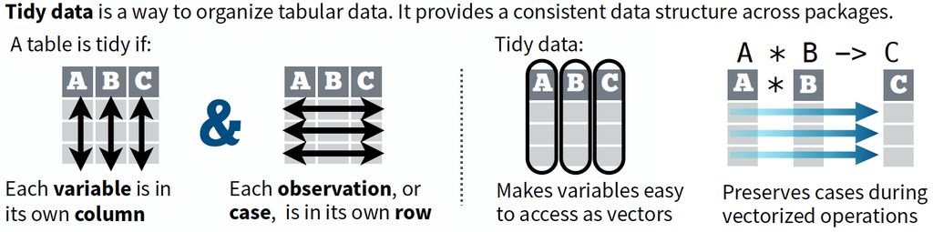

## Reshaping data

The four verbs to keep in mind for reshaping data with `tidyr` are:  
- `spread`  
- `gather`  
- `separate`  
- `unite`

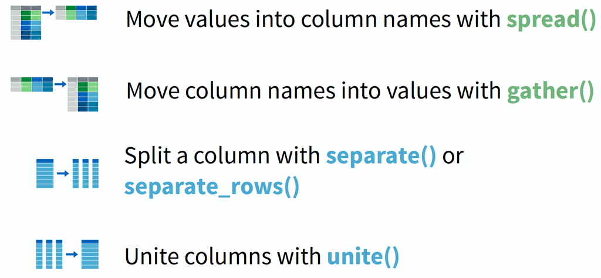

## Renaming columns

```r
names(count_summary_rna)
```

```
##  [1] "Geneid"                "Chr"                   "Start"
##  [4] "End"                   "Strand"                "Length"
##  [7] "0h_1_RNA_S13_umi.bam"  "0h_2_RNA_S14_umi.bam"  "0h_3_RNA_S15_umi.bam"
## [10] "14h_1_RNA_S22_umi.bam" "14h_2_RNA_S23_umi.bam" "14h_3_RNA_S24_umi.bam"
## [13] "4h_1_RNA_S16_umi.bam"  "4h_2_RNA_S17_umi.bam"  "4h_3_RNA_S18_umi.bam"
## [16] "8h_1_RNA_S19_umi.bam"  "8h_2_RNA_S20_umi.bam"  "8h_3_RNA_S21_umi.bam"
```

```r
#create a new file to preserve original data
count_summary_rna_mod <- count_summary_rna
```

##rename columns in the new dataframe

```r
names(count_summary_rna_mod) <-
  c("ensembl_transcript_id", "chr", "start", "end", "strand", "length",
    "rna_0h_rep1", "rna_0h_rep2", "rna_0h_rep3",
    "rna_14h_rep1", "rna_14h_rep2", "rna_14h_rep3",
    "rna_4h_rep1", "rna_4h_rep2", "rna_4h_rep3",
    "rna_8h_rep1", "rna_8h_rep2", "rna_8h_rep3")
```

## Removing columns/rows

```r
#only keep count data
count_summary_rna_mod <- count_summary_rna_mod[, c(1, 7:18)]

names(count_summary_rna_mod)
```

```
##  [1] "ensembl_transcript_id" "rna_0h_rep1"           "rna_0h_rep2"
##  [4] "rna_0h_rep3"           "rna_14h_rep1"          "rna_14h_rep2"
##  [7] "rna_14h_rep3"          "rna_4h_rep1"           "rna_4h_rep2"
## [10] "rna_4h_rep3"           "rna_8h_rep1"           "rna_8h_rep2"
## [13] "rna_8h_rep3"
```

## Reordering columns

```r
count_summary_rna_mod <- count_summary_rna_mod[, c(1:4, 8:13, 5:7)]
names(count_summary_rna_mod)
```

```
##  [1] "ensembl_transcript_id" "rna_0h_rep1"           "rna_0h_rep2"
##  [4] "rna_0h_rep3"           "rna_4h_rep1"           "rna_4h_rep2"
##  [7] "rna_4h_rep3"           "rna_8h_rep1"           "rna_8h_rep2"
## [10] "rna_8h_rep3"           "rna_14h_rep1"          "rna_14h_rep2"
## [13] "rna_14h_rep3"
```

## Tidying the data

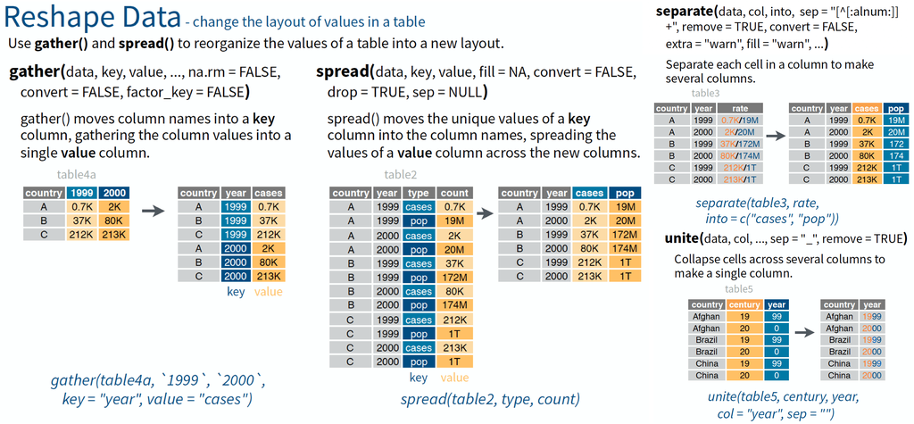

## Tidying the data (cont’d)

```r
count_summary_rna_mod <- gather(data = count_summary_rna_mod,
              "rna_0h_rep1", "rna_0h_rep2", "rna_0h_rep3",
              "rna_4h_rep1", "rna_4h_rep2", "rna_4h_rep3",
              "rna_8h_rep1", "rna_8h_rep2", "rna_8h_rep3",
              "rna_14h_rep1", "rna_14h_rep2", "rna_14h_rep3",
              key = "condition", value = "count")
table(count_summary_rna_mod$condition)
```

```
##
##  rna_0h_rep1  rna_0h_rep2  rna_0h_rep3 rna_14h_rep1 rna_14h_rep2 rna_14h_rep3
##        20025        20025        20025        20025        20025        20025
##  rna_4h_rep1  rna_4h_rep2  rna_4h_rep3  rna_8h_rep1  rna_8h_rep2  rna_8h_rep3
##        20025        20025        20025        20025        20025        20025
```

## Tidying the data (cont’d)

```r
count_summary_rna_mod <- separate(data = count_summary_rna_mod,
              condition, sep = "_",
              into = c("type", "time", "replicate"))
table(count_summary_rna_mod$time)
```

```
##
##    0h   14h    4h    8h
## 60075 60075 60075 60075
```

```r
table(count_summary_rna_mod$replicate)
```

```
##
##  rep1  rep2  rep3
## 80100 80100 80100
```

## 5. Export the data for future use

```r
write.csv(count_summary_rna_mod,
          file = "1-class1/data/output/count_summary_rna_mod.csv")
```

## Acknowledgements

Most images, especially the cheat sheets, are from www.rstudio.com